# 2.7 Practical: binomial regression

Benjamin Rosenbaum

October 22, 2019

# Statistical model

Suppose we want to measure the effect of a continuous variable on presence / absence data.

E.g. presence of a species in different locations, $x$ = temperature in location.

Now we have $k$ trials per observation, $y$ counts the number of successful trials, so $y\in\{0,1,2,...,k\}$

Statistical model:
$$\begin{aligned}
y_i & \sim \text{binomial}(k,p_i) \\
\text{logit}(p_i) &= a+b\cdot x_i \\
\text {or, equivalently:}\quad p_i &= \text{inv.logit}(a+b\cdot x_i)
\end{aligned}$$
$p_i$ is the probability of presence of the species, the distribution of $y_i$ is binomial with $k$ trials.

We assume a linear relationship of $\text{logit}(p)$ with temperature. (Realistically, a hump-shaped relationship would make more sense.)

$\text{inv.logit}()$ transforms the values of the whole axis to the interval (0,1)

Research question: is there a positive effect of the predictor to the presence of the species?

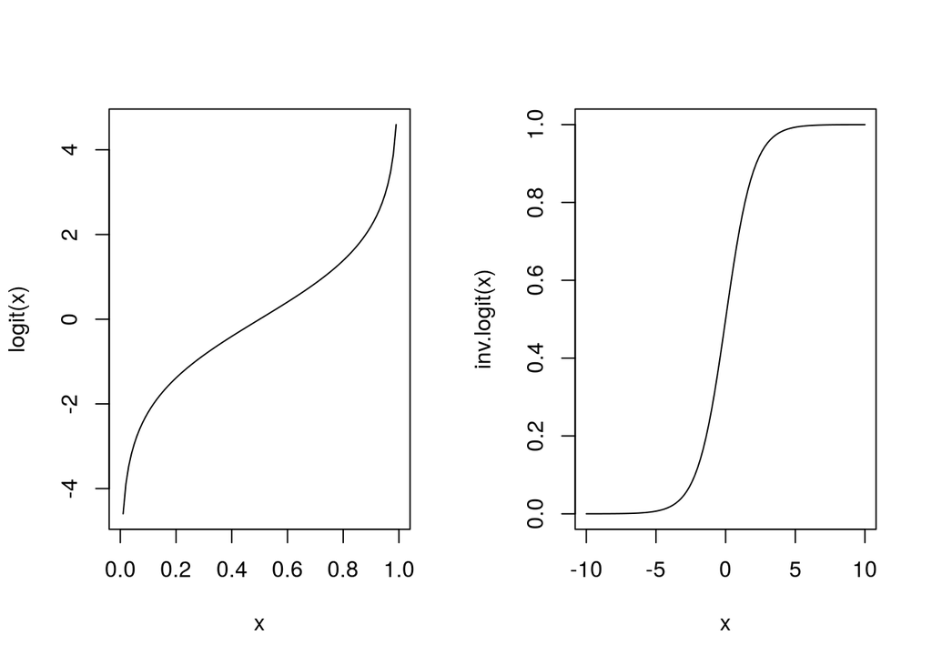

```r
library(boot)
par(mfrow=c(1,2))
curve(logit, from=0, to=1)
curve(inv.logit, from=-10, to=10)
```

Research question: is there a positive effect of the predictor to the presence of the species?

# Setup

```r
rm(list=ls())
library(rstan)
library(coda)
library(BayesianTools)
library(boot)
setwd("~/Desktop/teaching Bayes")

rstan_options(auto_write = TRUE)
options(mc.cores = 3)
```

# Generate data

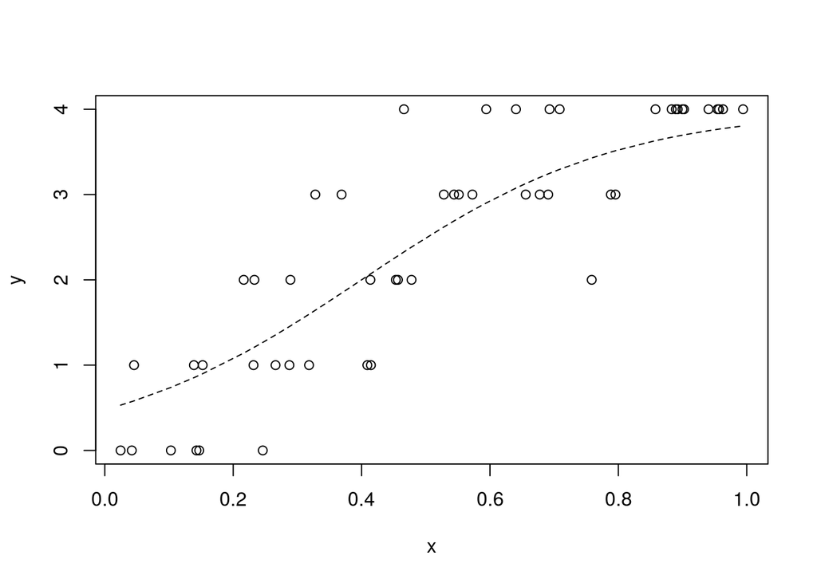

```r
set.seed(123) # initiate random number generator for reproducability
n = 50
x = sort(runif(n, 0, 1))

a = -2
b = 5

p = inv.logit(a+b*x)

y = rbinom(n=n, size=4, prob=p)

plot(x,y)
lines(x,4*p, lty=2)
```

# Stan code and fitting

```r
data = list(n=n,
            x=x,
            y=y)

stan_code = '
data {
  int n;
  vector[n] x;
  int y[n];
}
parameters {
  real a;
  real b;
}
model {
  // priors
  a ~ normal(0, 10);
  b ~ normal(0, 10);
  // likelihood
  y ~ binomial(4,inv_logit(a+b*x));
}
'

stan_model = stan_model(model_code=stan_code)
# save(stan_model, file="stan_model.RData")
# load("stan_model.RData")

fit  = sampling(stan_model,
                data=data,
                chains=3,
                iter=2000,
                warmup=1000
)

print(fit, digits=3, probs=c(0.025, 0.975))
```

```
## Inference for Stan model: 022a69e0cc0ea139ddfd1ac3774df15c.
## 3 chains, each with iter=2000; warmup=1000; thin=1;
## post-warmup draws per chain=1000, total post-warmup draws=3000.
##
##         mean se_mean    sd    2.5%   97.5% n_eff  Rhat
## a     -2.582   0.016 0.417  -3.389  -1.813   709 1.002
## b      6.522   0.034 0.891   4.873   8.279   705 1.001
## lp__ -88.252   0.032 1.022 -91.000 -87.282  1006 1.000
##
## Samples were drawn using NUTS(diag_e) at Mon Oct 14 13:50:12 2019.
## For each parameter, n_eff is a crude measure of effective sample size,
## and Rhat is the potential scale reduction factor on split chains (at
## convergence, Rhat=1).
```

```
## ci_level: 0.8 (80% intervals)
```

```
## outer_level: 0.95 (95% intervals)
```

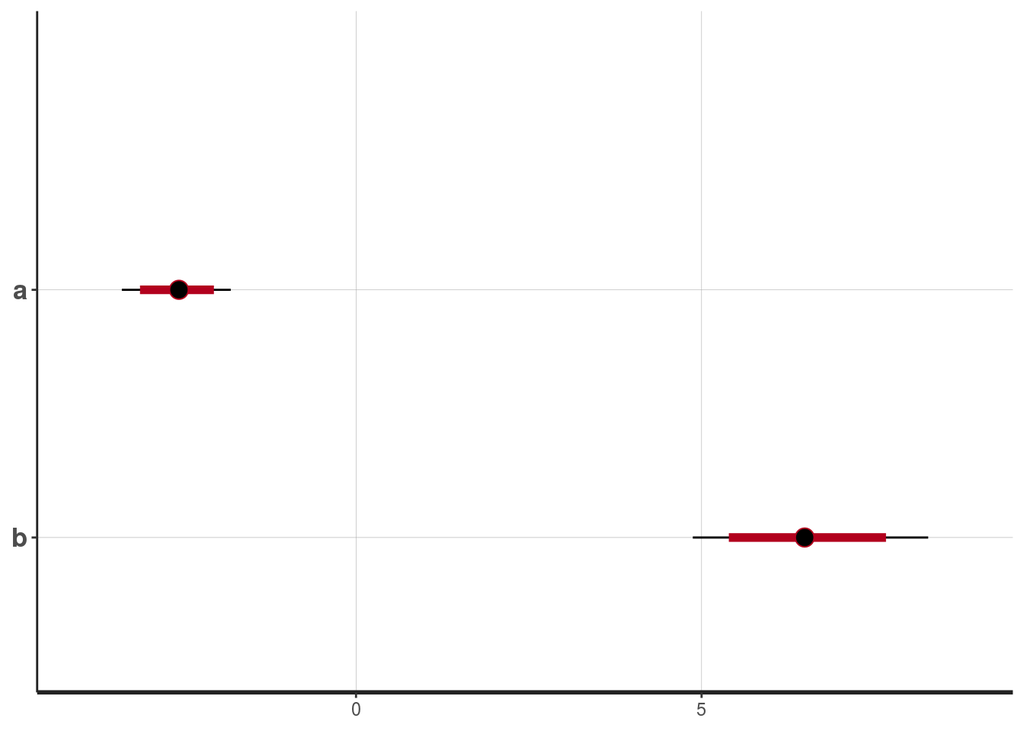

```r
plot(fit)
```

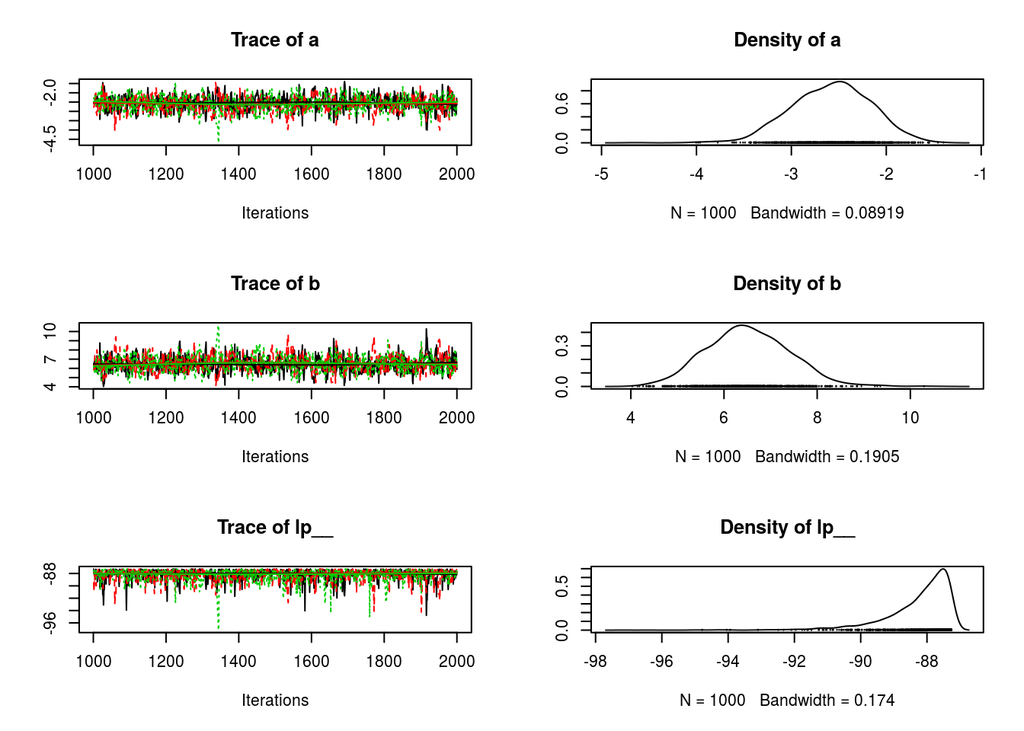

```r
plot(As.mcmc.list(fit)) # from coda package
```

```r
posterior=as.matrix(fit)

str(posterior)
```

```
##  num [1:3000, 1:3] -2.56 -2.59 -2.56 -2.47 -2.58 ...
##  - attr(*, "dimnames")=List of 2
##   ..$ iterations: NULL
##   ..$ parameters: chr [1:3] "a" "b" "lp__"
```

# Predictions

First, we generate credible intervals for the determinstic model. (90%, but choose as you like)

The deterministic model is `p = inv.logit(a+b*x)`, the probability of a successful trial.

But there are `k=4` trials, so the expected value of successful trials is `4*p`.

Later, we generate prediction intervals for the data (for y) using also the stochastic part.

```r
x.pred = seq(from=0, to=1, by=0.01)
y.cred = matrix(0, nrow=nrow(posterior), ncol=length(x.pred))

for(i in 1:nrow(posterior)){
  y.cred[i, ] = 4 * inv.logit(posterior[i,"a"] + posterior[i,"b"]*x.pred)
}
```

Example: First 100 realizations from the posterior

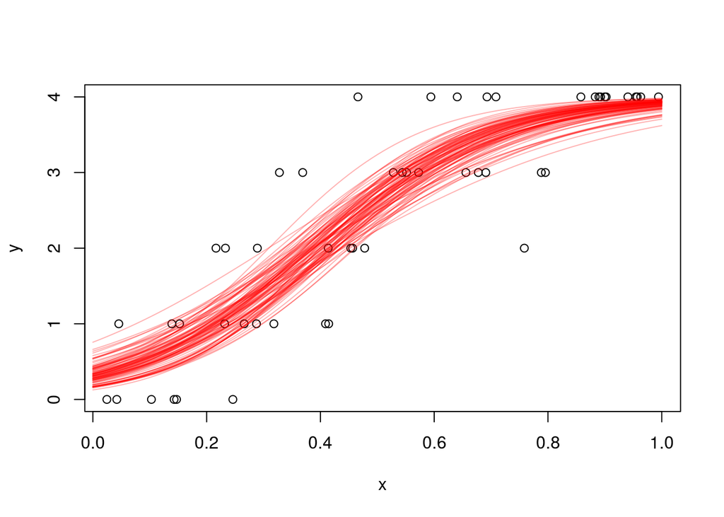

```r
plot(x,y)
for(i in 1:100){
  lines(x.pred, y.cred[i, ], col=adjustcolor("red", alpha.f=0.3))
}
```

Now, the credible intervals using the whole distribution

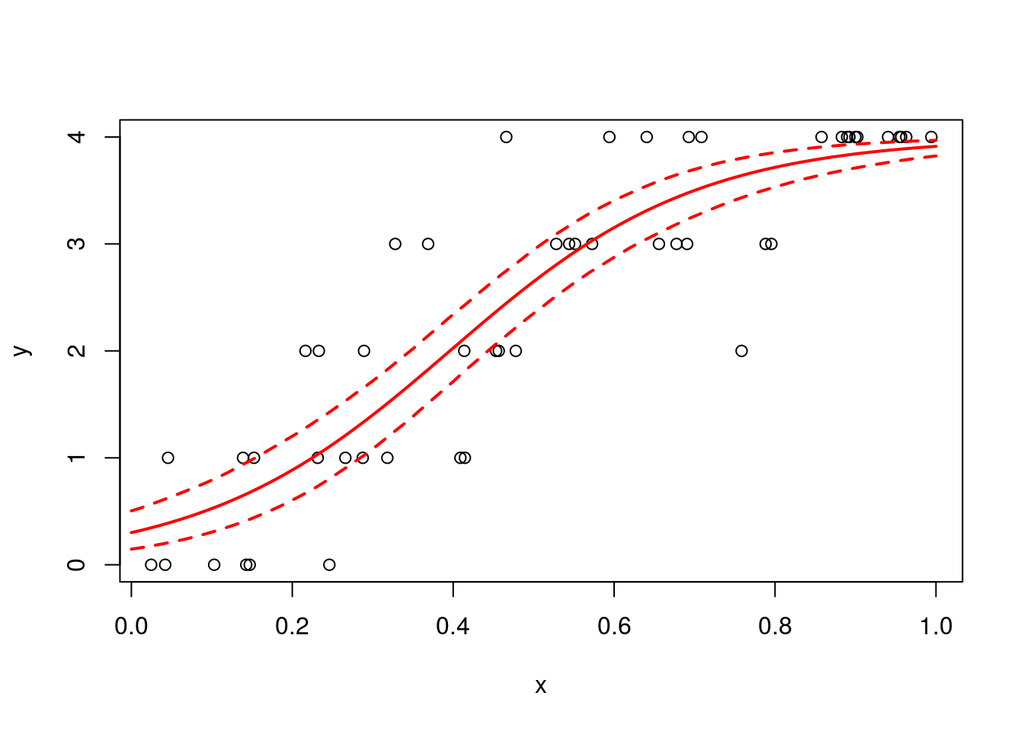

```r
plot(x,y)

y.cred.mean = apply(y.cred, 2, function(x) mean(x))
lines(x.pred, y.cred.mean, col="red", lwd=2)

y.cred.q05 = apply(y.cred, 2, function(x) quantile(x, probs=0.05))
lines(x.pred, y.cred.q05, col="red", lwd=2, lty=2)

y.cred.q95 = apply(y.cred, 2, function(x) quantile(x, probs=0.95))
lines(x.pred, y.cred.q95, col="red", lwd=2, lty=2)
```

Now, we draw predicted data from the binomial distribution (k=4 trials) in the statistical model.

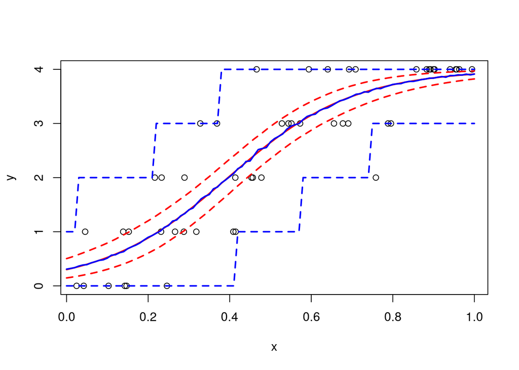

```r
y.pred = matrix(0, nrow=nrow(posterior), ncol=length(x.pred))
for(i in 1:nrow(posterior)){
  y.pred[i, ] = rbinom(n=length(x.pred), size=4, p=inv.logit(posterior[i,"a"] + posterior[i,"b"]*x.pred))
}

plot(x,y)

lines(x.pred, y.cred.mean, col="red", lwd=2)
lines(x.pred, y.cred.q05, col="red", lwd=2, lty=2)
lines(x.pred, y.cred.q95, col="red", lwd=2, lty=2)

y.pred.mean = apply(y.pred, 2, function(x) mean(x))
lines(x.pred, y.pred.mean, col="blue", lwd=2)

y.pred.q05 = apply(y.pred, 2, function(x) quantile(x, probs=0.05))
lines(x.pred, y.pred.q05, col="blue", lwd=2, lty=2)

y.pred.q95 = apply(y.pred, 2, function(x) quantile(x, probs=0.95))
lines(x.pred, y.pred.q95, col="blue", lwd=2, lty=2)
```

# Frequentist solution

```r
# 1st column successes, 2nd column fails (if there are y successes, there must be k-y fails)
y.succ.fail = cbind(y, 4-y)
summary(glm(y.succ.fail~x, family=binomial(link="logit")))
```

```
##
## Call:
## glm(formula = y.succ.fail ~ x, family = binomial(link = "logit"))
##
## Deviance Residuals:
##     Min       1Q   Median       3Q      Max
## -2.1273  -0.5672   0.1770   0.5804   1.9902
##
## Coefficients:
##             Estimate Std. Error z value Pr(>|z|)
## (Intercept)  -2.5608     0.4221  -6.067 1.30e-09 ***
## x             6.4514     0.8887   7.259 3.89e-13 ***
## ---
## Signif. codes:  0 '***' 0.001 '**' 0.01 '*' 0.05 '.' 0.1 ' ' 1
##
## (Dispersion parameter for binomial family taken to be 1)
##
##     Null deviance: 133.164  on 49  degrees of freedom
## Residual deviance:  39.701  on 48  degrees of freedom
## AIC: 93.916
##
## Number of Fisher Scoring iterations: 5
```